# Reproducible Research: Peer Assessment 1

## Loading and preprocessing the data

```r
data_full <- read.csv("activity.csv")
```

## What is mean total number of steps taken per day?

Histogram of the total number of steps taken each day:

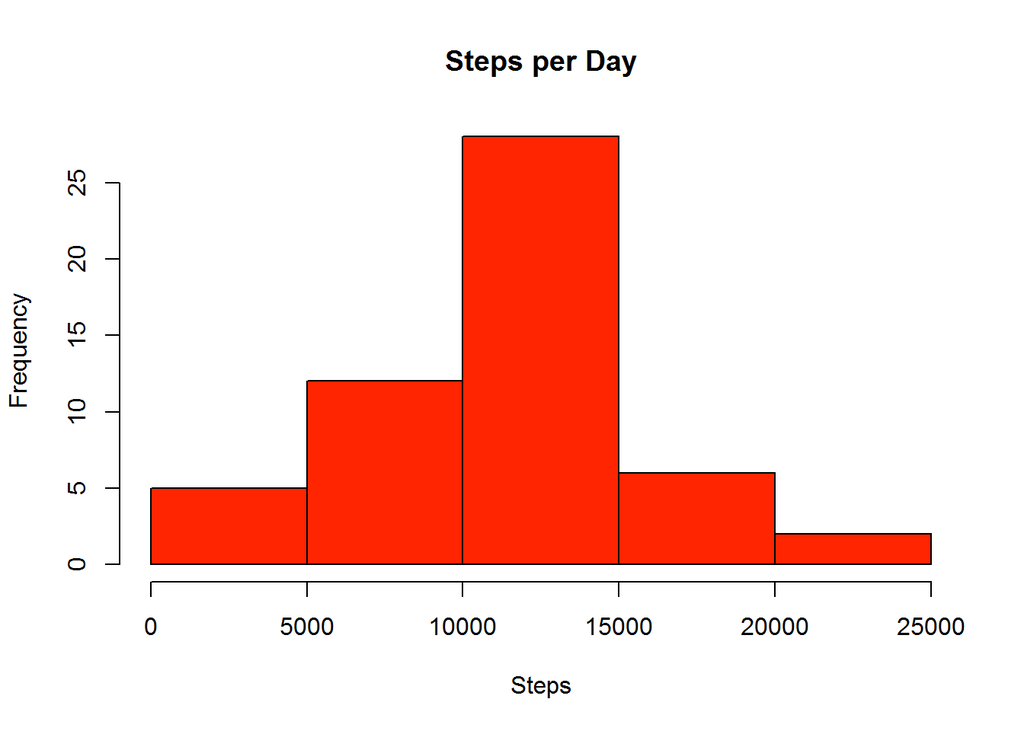

```r
data <- na.omit(data_full)
steps_per_day <- aggregate(steps ~ date, data, sum)
hist(steps_per_day$steps, main="Steps per Day", xlab="Steps", col=rgb(255, 37, 0, maxColorValue=255));
```

Mean of the total numbers of steps per day:

```r
mean(steps_per_day$steps)
```

```
## [1] 10766.19
```

Median of the total numbers of steps per day:

```r
median(steps_per_day$steps)
```

```
## [1] 10765
```

## What is the average daily activity pattern?

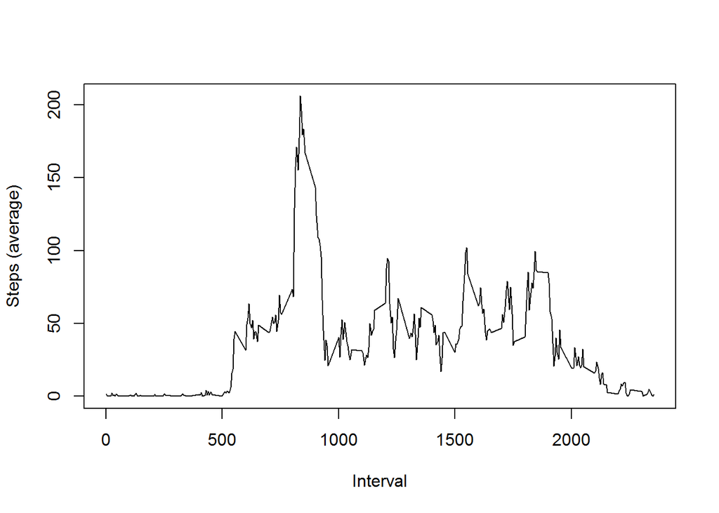

```r
avg_steps_per_interval <- aggregate(steps ~ interval, data, mean)
y <- avg_steps_per_interval$steps;
x <- avg_steps_per_interval$interval;
plot(x, y, type="l", ylab="Steps (average)", xlab="Interval");
```

5-minute interval (on average across all the days in the dataset) wich contains the maximum number of steps:

```r
max_index <- which.max(avg_steps_per_interval$steps)
avg_steps_per_interval[max_index,]$interval
```

```
## [1] 835
```

## Imputing missing values

Total number of missing values in the dataset:

```r
nas <- data_full[is.na(data_full$steps), ]
nrow(nas)
```

```
## [1] 2304
```

Filling in all of the NAs with the average value of steps of each interval:

```r
data_filled <- data_full
for (i in 1:nrow(data_filled))  {
        if(is.na(data_filled[i, ]$steps)){
                data_filled[i, ]$steps <- avg_steps_per_interval[avg_steps_per_interval$interval == data_filled[i, ]$interval, ]$steps
                }
        }
```

Histogram of the total number of steps taken each day (using the dataset filled previously):

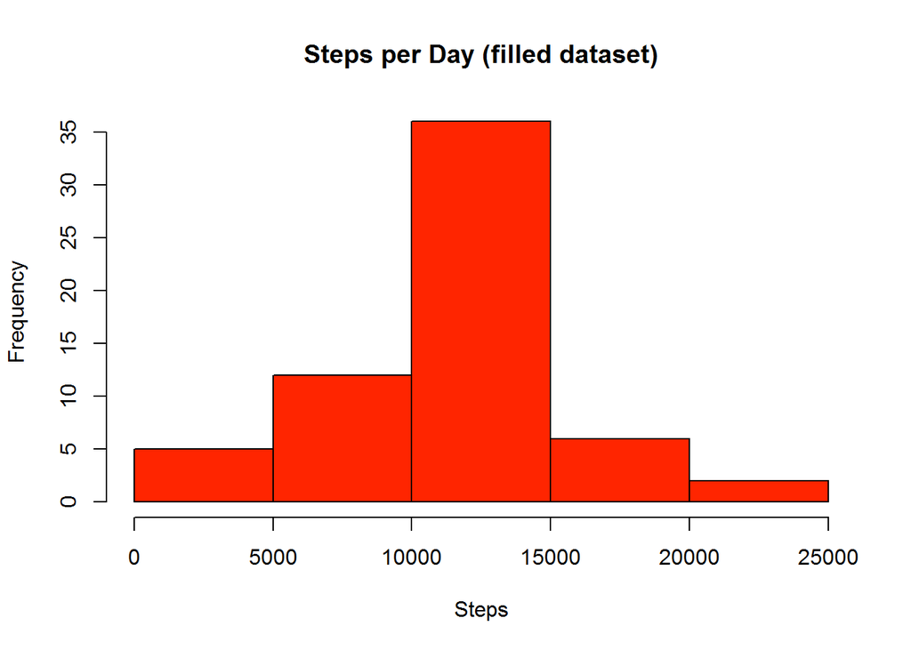

```r
steps_per_day_filled <- aggregate(steps ~ date, data_filled, sum)
hist(steps_per_day_filled$steps, main="Steps per Day (filled dataset)", xlab="Steps", col=rgb(255, 37, 0, maxColorValue=255));
```

Mean of the total numbers of steps per day (using the dataset filled previously):

```r
mean(steps_per_day_filled$steps)
```

```
## [1] 10766.19
```

Median of the total numbers of steps per day (using the dataset filled previously):

```r
median(steps_per_day_filled$steps)
```

```
## [1] 10766.19
```

The value of the mean does not differ from the estimated value in the first part of the assignment. The value of the median differs from the estimated value in the first part of the assignment.

By imputing missing data on the estimates of the total daily number of steps, the precision of the analysis can be compromised.

## Are there differences in activity patterns between weekdays and weekends?

```r
library(lattice)
Sys.setlocale("LC_TIME", "English");
```

```
## [1] "English_United States.1252"
```

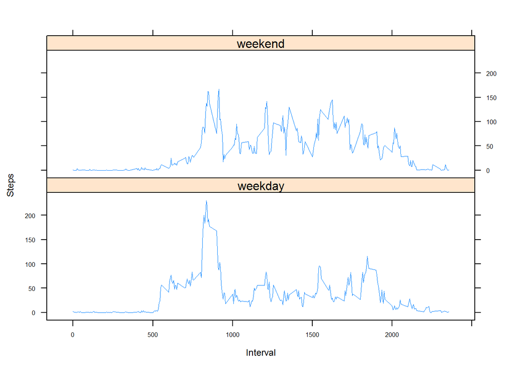

```r
par(mfrow = c(2,1));
criteria <- weekdays(as.Date(data_filled$date)) == "Saturday" | weekdays(as.Date(data_filled$date)) == "Sunday"
data_filled$day <- ifelse(criteria,"weekend", "weekday")
data_filled$day <- as.factor(data_filled$day)
avg_steps_per_interval_filled_weekend <- aggregate(steps ~ interval, data_filled[data_filled$day == "weekend", ], mean)
avg_steps_per_interval_filled_weekday <- aggregate(steps ~ interval, data_filled[data_filled$day == "weekday", ], mean)
avg_steps_per_interval_filled_weekend$day <- "weekend"
avg_steps_per_interval_filled_weekday$day <- "weekday"
final <- rbind(avg_steps_per_interval_filled_weekend, avg_steps_per_interval_filled_weekday)
final$day <- as.factor(final$day)
xyplot(steps~interval|day,
       data = final,
       type="l",
       layout=c(1,2),
       xlab=list(label="Interval", cex=0.75), ylab=list(label="Steps",cex=0.75), scales=list(cex=0.5), lwd=0.1)
```